# Лабораторная работа №7

Модель рекламной кампании

Ван И

Российский университет дружбы народов, Москва, Россия

25 марта 2023

# Информация

## Докладчик

- Ван И
- студент уч. группы НФИбд-02-20
- Российский университет дружбы народов
- [1032198069@pfur.ru]

# Вводная часть

## Актуальность

- Необходимость навыков моделирования реальных математических задач, построение графиков.

## Объект и предмет исследования

- Язык программирования Julia
- Язык моделирования Modelica
- Модель рекламной кампании

## Цели и задачи

- Продолжить знакомство с функционалом языков Julia и Modelica.
- Описать математическую модель рекламной кампании с помощью данных языков.
- Построить графики состояния систем в соответствии с поставленными задачами.

## Материалы и методы

- Языки:
  - язык программирования Julia
  - язык моделирования Modelica
- Дополнительный комплекс программ:
  - Программное обеспечение OpenModelica

# Процесс выполнения работы

# Формулировка задания

Постройте график распространения рекламы, математическая модель которой описывается следующим уравнением:

1. $\frac{dn}{dt} = (0.895+0.0000433n(t))(N-n(t))$
2. $\frac{dn}{dt} = (0.0000145+0.295n(t))(N-n(t))$
3. $\frac{dn}{dt} = (0.196 \cdot t + 0.699 \cdot t \cdot n(t))(N-n(t))$

# Теоретическое введение

Математическая модель рекламной кампании описывается следующим ОДУ:

$$\frac{dn}{dt} = (\alpha_1(t) +
\alpha_2(t)n(t))(N-n(t)),$$

где *N* — число потенциальных клиентов; *n*(*t*) — число клиентов, информированных о товаре и готовых его купить; $\frac{dn}{dt}$ — изменение числа клиентов, информированных о товаре и готовых его купить, со временем; *α*<sub>1</sub>(*t*) — величина, характеризующая интенсивность рекламной компании; *α*<sub>2</sub>(*t*) — величина, характеризующая интенсивность т.н. «сарафанного радио».

# Julia

## Получившийся график задания №1

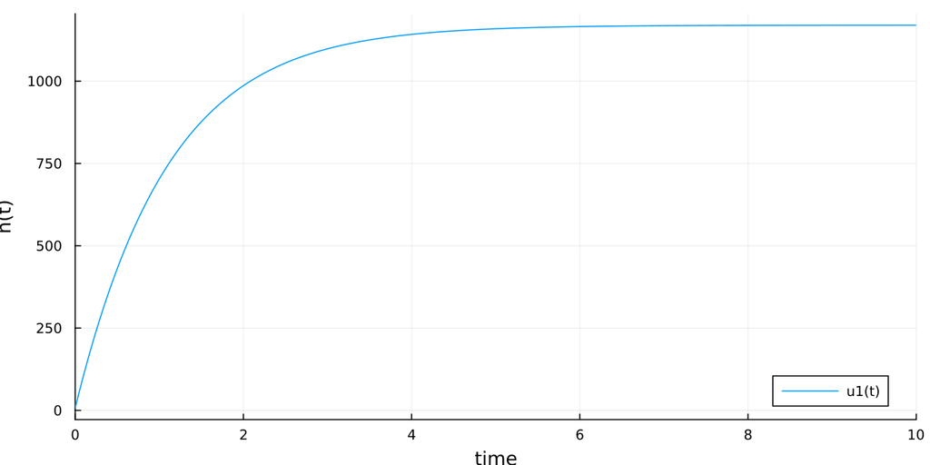

## Получившийся график задания №2

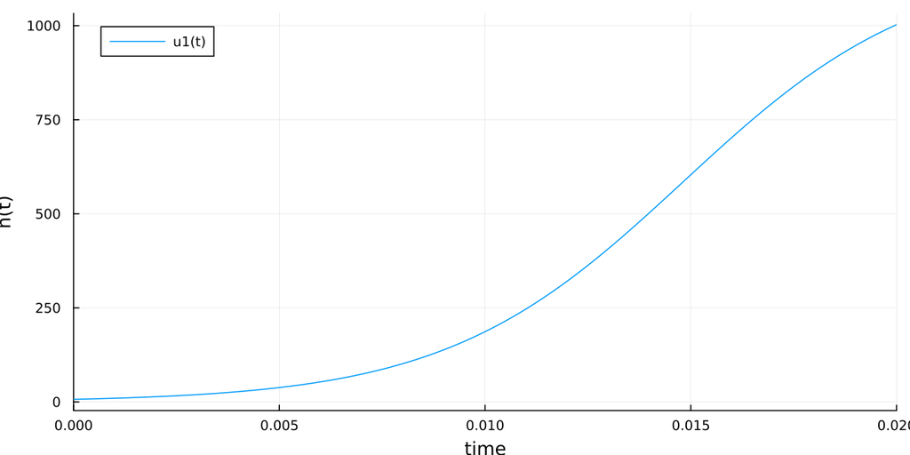

## Получившийся график задания №3

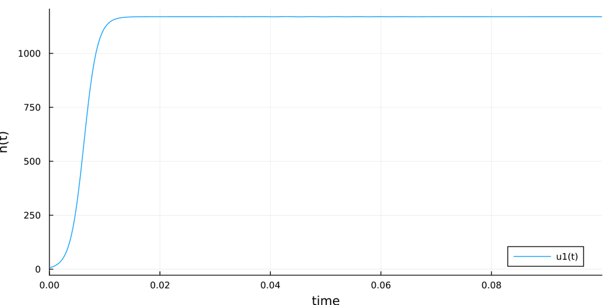

# OpenModelica

## Получившийся график задания №1

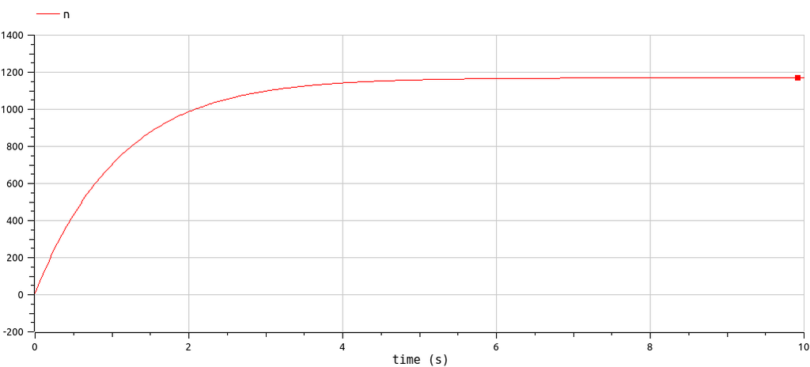

## Получившийся график задания №2

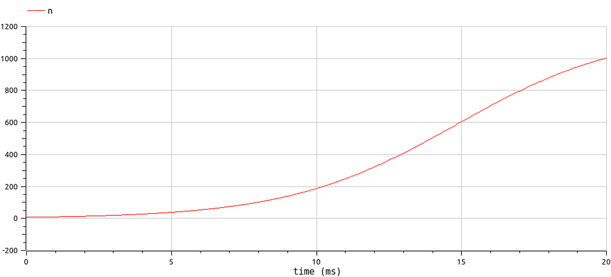

## Получившийся график задания №3

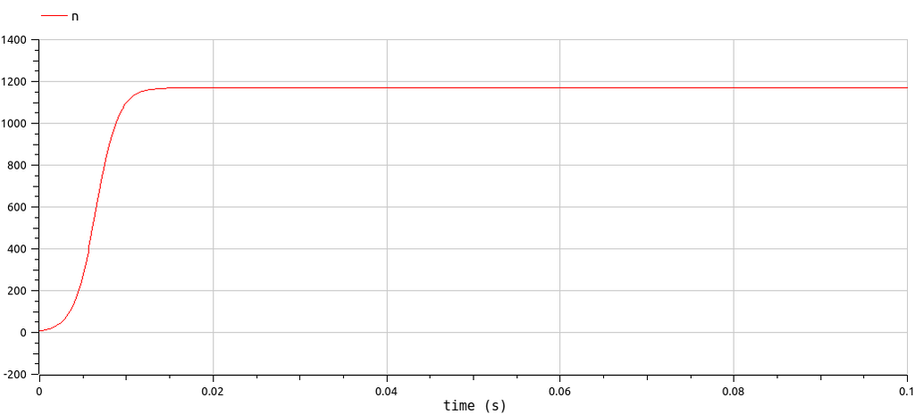

# Результаты

- Описана математическая модель рекламной кампании с помощью языков Julia и Modelica.
- Построены графики состояния систем в соответствии с поставленными задачами.

## Вывод

Продолжил знакомство с функционалом языка программирования Julia и языка моделирования Modelica. Используя эти средства, построил математическую модель рекламной кампании.